# Leaf Area Prediction using Multiple Linear Regression

Jonathan Cárdenas

2023-04-04

```r
raw_data <- read.csv("harvest_complete.csv")
raw_data$treatment <-as.factor(with(raw_data, ifelse(tray_id == '1', '280 ppm',
                                                     ifelse(tray_id == 2, '160 ppm', '80 ppm'))))
```

Select a random sample of 33 entries for the last two harvest:

```r
set.seed(123)
harvest_1 <-raw_data %>% filter(date == '02/02/2023')

harvest_2 <- raw_data %>% filter(date == '09/02/2023') %>% sample_n(33)

harvest_3 <-  raw_data %>% filter(date == '23/02/2023') %>% sample_n(33)

harvest_sample <- bind_rows(harvest_1,harvest_2,harvest_3)
```

Create 3 dataframes for predictors, response variable and combination of both

```r
img_predictors <- harvest_sample %>% dplyr::select(10:24) #1
LA<- harvest_sample %>% dplyr::select('LA_mm2')
img_LA <- harvest_sample %>% dplyr::select(7:9, 12:24) #3
```

Select a representative number of features according to BIC analysis performed in the markdown for feature selection

```r
BIC_features <-  img_LA %>% dplyr::select(LFW_g,LDW_g,height_mm, plant_height)
```

Data standarization:

```r
stand_bbmisc <- normalize(BIC_features, method = 'standardize')
new_dataset<- stand_bbmisc %>%
  mutate(LA_mm2 = LA$LA_mm2)
```

Separate data in train and test data:

```r
# Use a random forest model to predict LFW, this time splitting the dataset.
train_id<- sample(1:nrow(new_dataset),0.7*nrow(new_dataset))
train_set<- new_dataset[train_id,]
test_set<- new_dataset[-train_id,]
```

```r
MLR_model <- lm(LA_mm2~., data = train_set)
summary(MLR_model)
```

```
##
## Call:
## lm(formula = LA_mm2 ~ ., data = train_set)
##
## Residuals:
##     Min      1Q  Median      3Q     Max
## -67.857  -5.925   0.034   6.071  75.267
##
## Coefficients:
##              Estimate Std. Error t value Pr(>|t|)
## (Intercept)   543.649      3.058 177.797  < 2e-16 ***
## LFW_g         187.065     57.386   3.260  0.00179 **
## LDW_g         455.481     67.489   6.749 5.12e-09 ***
## height_mm      28.807     15.479   1.861  0.06733 .
## plant_height  -22.832     20.230  -1.129  0.26327
## ---
## Signif. codes:  0 '***' 0.001 '**' 0.01 '*' 0.05 '.' 0.1 ' ' 1
##
## Residual standard error: 24.85 on 64 degrees of freedom
## Multiple R-squared:  0.9986, Adjusted R-squared:  0.9985
## F-statistic: 1.119e+04 on 4 and 64 DF,  p-value: < 2.2e-16
```

From now on, we will use the test set to perform predictions and to calculate all the performance statistics.

```r
MLR_prediction <- predict(MLR_model, newdata = test_set)
```

Notice that the R-squared value obtained below is not the same as the R-quared given by the model’s summary. For this R-squared we are correlating the predicted values and the labels from the test set.

MSE displayed is not the same as the summary MSE neither. The MSE we are calculating here is mean squared error of the model’s prediction on the testing data. This metric measures how well the model generalizes to new, unseen data.

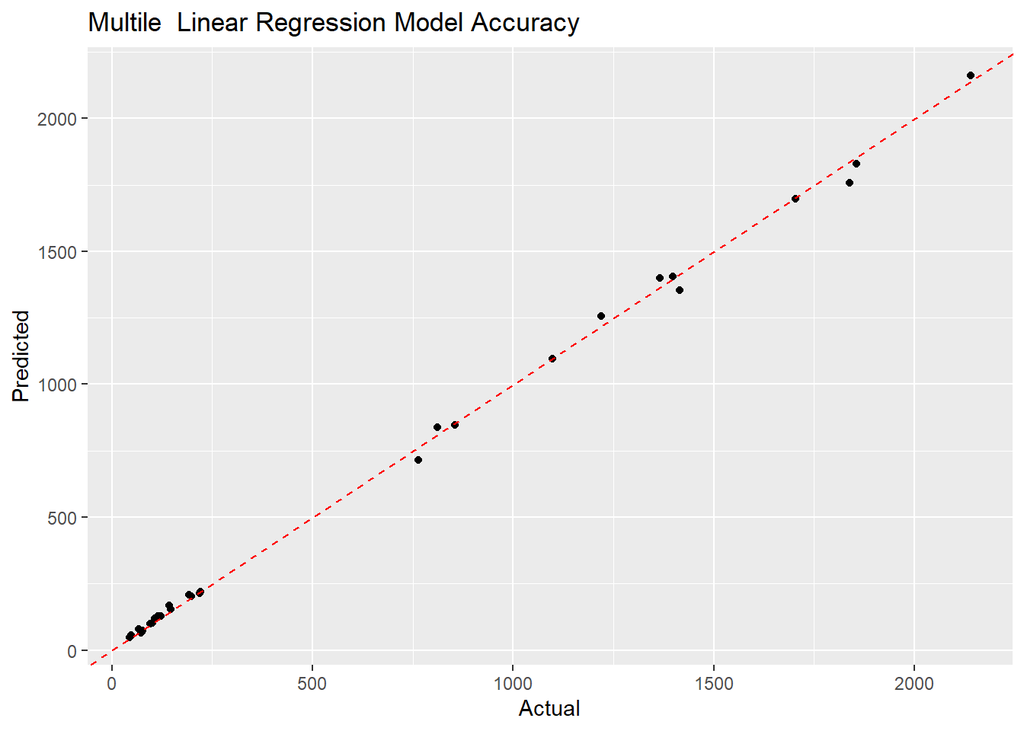

```r
ggplot(data.frame(actual = test_set$LA_mm2, predicted = MLR_prediction), aes(x = actual, y = predicted)) +
  geom_point() +
  geom_abline(slope = 1, intercept = 0, color = "red", linetype = "dashed") +
  labs(x = "Actual", y = "Predicted", title = "Multile  Linear Regression Model Accuracy")
```

```r
# Evaluate the model performance: On new, unseen data.
MAE <- mean(abs(MLR_prediction - test_set$LA_mm2))
MSE <- mean((MLR_prediction - test_set$LA_mm2)^2)
R_squared <- cor(MLR_prediction,test_set$LA_mm2)^2
RMSE<- RMSE(MLR_prediction,test_set$LA_mm2)

# Print the performance metrics
cat("Mean Absolute Error (MAE): ", MAE, "\n")
```

```
## Mean Absolute Error (MAE):  16.74493
```

```r
cat("Mean Squared Error (MSE): ", MSE, "\n")
```

```
## Mean Squared Error (MSE):  636.9574
```

```r
cat("R-squared: ", R_squared, "\n")
```

```
## R-squared:  0.9986963
```

```r
cat("RMSE (Prediction): ", RMSE, "\n")
```

```
## RMSE (Prediction):  25.23801
```